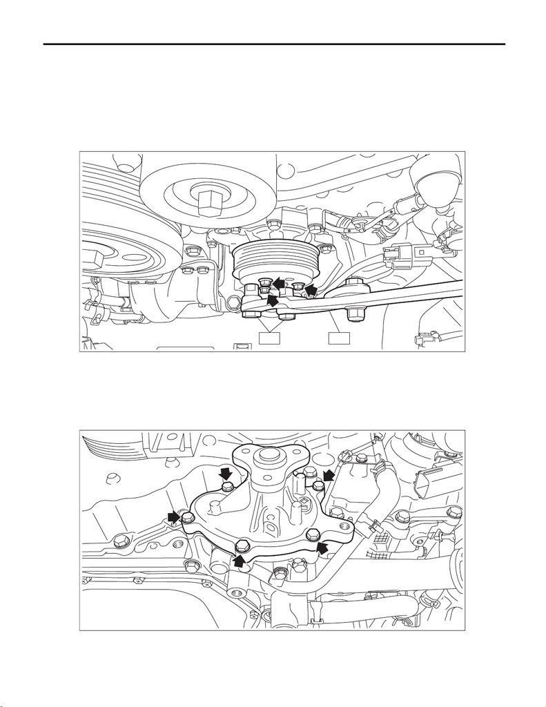

CO(w/o STI)-16

Water Pump

COOLING

4. Water Pump

A: REMOVAL

1. WATER PUMP PULLEY

1) Remove the V-belts. <Ref. to ME(w/o STI)-78, REMOVAL, V-belt.>

2) Remove the water pump pulley using the ST.

ST1 18355AA000 PULLEY WRENCH

ST2 18334AA030 PULLEY WRENCH PIN SET

2. WATER PUMP

1) Disconnect the ground terminal from battery sensor. <Ref. to NT-5, BATTERY, NOTE, Note.>

3) Remove the front exhaust pipe. <Ref. to EX(w/o STI)-9, REMOVAL, Front Exhaust Pipe.>

4) Remove the water pump from the oil pan upper.

CO-03373

ST1ST2

CO-03213

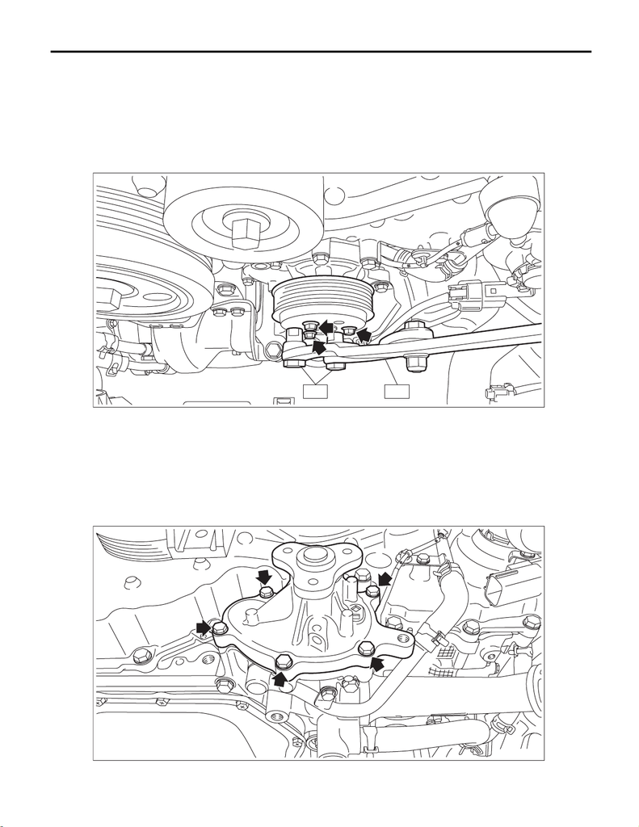

CO(w/o STI)-17

Water Pump

COOLING

B: INSTALLATION

1. WATER PUMP PULLEY

1) Using the ST, install the water pump pulley.

ST1 18355AA000 PULLEY WRENCH

ST2 18334AA030 PULLEY WRENCH PIN SET

Tightening torque:

14 N·m (1.4 kgf-m, 10.3 ft-lb)

2) Install the V-belts. <Ref. to ME(w/o STI)-81, INSTALLATION, V-belt.>

2. WATER PUMP

1) Install the water pump to oil pan upper.

NOTE:

Use a new gasket.

Tightening torque:

6.4 N·m (0.7 kgf-m, 4.7 ft-lb)

2) Install the front exhaust pipe. <Ref. to EX(w/o STI)-19, INSTALLATION, Front Exhaust Pipe.>

CO-03373

ST1ST2

CO-03213

[figure not shown]

CO(w/o STI)-18

Water Pump

COOLING

4) Connect the ground terminal to battery sensor. <Ref. to NT-5, BATTERY, NOTE, Note.>

C: INSPECTION

1) Check that the water pump pulley does not have deformation, cracks and any other damage.

2) Check the water pump bearing for smooth rotation.

3) Make sure the impeller is not abnormally deformed or damaged.